# IODS course project

## Divide and Conquer

We now need to divide the dataset so that 80% belongs to the train set. We will then test predictions on the data and test how well the model works.

```r
#The number of rows in the Boston data set
n <- nrow(boston_scaled)

#Choosing randomly 80% of the rows
ind <- sample(n,  size = n * 0.8)

#Creating 'train' set (80% of the rows)
train <- boston_scaled[ind,]

#Creating 'test' set (20% of the rows)
test <- boston_scaled[-ind,]

#Let us save the correct classes from 'test' data
correct_classes <- test$crime

#And remove the crime variable from 'test' data
test <- dplyr::select(test, -crime)
```

##LDA analysis

We now run a LDA and create a biplot with the data to see how the grouping works with our data.

```r
#A linear discriminant analysis (LDA)
#Crime rate as target variable, all the others (.) as predictor variables
lda.fit <- lda(crime ~ ., data = train)

#Printing the lda.fit object
lda.fit
```

```
## Call:
## lda(crime ~ ., data = train)
##
## Prior probabilities of groups:
##       low   med_low  med_high      high
## 0.2673267 0.2475248 0.2500000 0.2351485
##
## Group means:
##                  zn      indus        chas        nox          rm        age
## low       0.9562901 -0.8953109 -0.09005591 -0.8876112  0.47011386 -0.8921449
## med_low  -0.1247140 -0.2634673 -0.03610305 -0.5539899 -0.11489100 -0.3547178
## med_high -0.3845049  0.2662960  0.15646403  0.4820549  0.05546345  0.5104879
## high     -0.4872402  1.0149946 -0.02367011  1.0582820 -0.47337702  0.8268763
##                 dis        rad        tax     ptratio       black       lstat
## low       0.8646493 -0.6788035 -0.7210530 -0.45932910  0.37461587 -0.75556879
## med_low   0.3100381 -0.5603838 -0.4776227 -0.00440362  0.30897432 -0.13253817
## med_high -0.4438070 -0.3985409 -0.2623010 -0.27855590  0.07254839  0.08289892
## high     -0.8585915  1.6596029  1.5294129  0.80577843 -0.66507955  0.83180762
##                  medv
## low       0.538169519
## med_low   0.002848035
## med_high  0.116466451
## high     -0.684559418
##
## Coefficients of linear discriminants:
##                  LD1          LD2         LD3
## zn       0.130469761  0.562479564 -0.96844278
## indus   -0.001688114 -0.178530084  0.26423226
## chas    -0.048382755 -0.004058043  0.09525711
## nox      0.253753471 -0.858786598 -1.15737204
## rm      -0.095604971 -0.062427345 -0.14543807
## age      0.411934838 -0.386371704 -0.31719527
## dis     -0.090574513 -0.233686324  0.07058975
## rad      3.235179663  1.049181654 -0.21329444
## tax     -0.003435036 -0.084090985  0.54338930
## ptratio  0.103013765 -0.024795957 -0.11117778
## black   -0.137641064 -0.008286353  0.08586766
## lstat    0.123038035 -0.190656246  0.41212347
## medv     0.120939373 -0.387970988 -0.08735342
##
## Proportion of trace:
##    LD1    LD2    LD3
## 0.9435 0.0436 0.0129
```

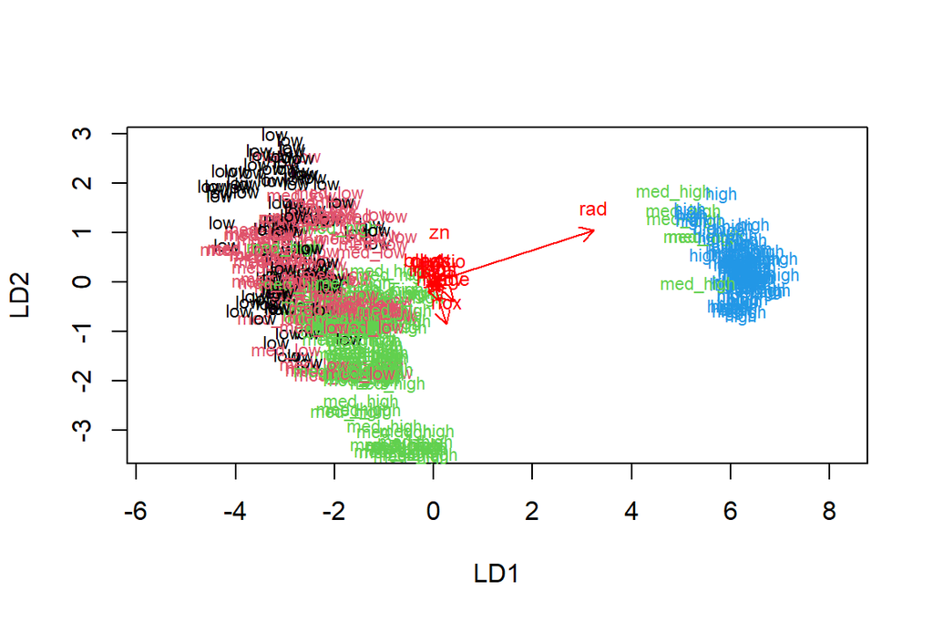

```r
#The function for lda biplot arrows
lda.arrows <- function(x, myscale = 1, arrow_heads = 0.1, color = "red", tex = 0.75, choices = c(1,2)){
  heads <- coef(x)
  arrows(x0 = 0, y0 = 0,
         x1 = myscale * heads[,choices[1]],
         y1 = myscale * heads[,choices[2]], col=color, length = arrow_heads)
  text(myscale * heads[,choices], labels = row.names(heads),
       cex = tex, col=color, pos=3)
}

#Target classes as numeric
classes <- as.numeric(train$crime)

#Plotting the results of lda
plot(lda.fit, dimen = 2, col = classes, pch = classes)
lda.arrows(lda.fit, myscale = 1)
```

From the plot above, we see that rad has a lot of influence over the separation of the data.

```r
lda.pred <- predict(lda.fit, newdata = test)

#Cross tabulation of the results
table(correct = correct_classes, predicted = lda.pred$class)
```

```
##           predicted
## correct    low med_low med_high high
##   low       12       7        0    0
##   med_low    5      17        4    0
##   med_high   1      12       12    0
##   high       0       0        1   31
```

## Clustering

We now standardize the dataset and calculate distances.

```r
#Scaling and standardizing the data set 'Boston'
boston_scaled1 <- scale(Boston)

#Changing the object to data frame
boston_scaled2 <- as.data.frame(boston_scaled1)


#Euclidean distance matrix
dist_eu <- dist(boston_scaled2)

#Let us see the summary of the distances
summary(dist_eu)
```

```
##    Min. 1st Qu.  Median    Mean 3rd Qu.    Max.
##  0.1343  3.4625  4.8241  4.9111  6.1863 14.3970
```

```r
#Manhattan distance matrix
dist_man <- dist(boston_scaled2, method = "manhattan")

#Let us now see the summary of the distances again
summary(dist_man)
```

```
##    Min. 1st Qu.  Median    Mean 3rd Qu.    Max.
##  0.2662  8.4832 12.6090 13.5488 17.7568 48.8618
```